# Between-Sample (Beta) Diversity

Shawn Xinyu Wang

April 29, 2025

# Set up

## Timing of this script

```r
# What time did we start running this script?
start_time <- Sys.time()
```

## Set the seed

```r
set.seed(238428)
```

## Load Packages, colors & functions

```r
pacman::p_load(tidyverse, devtools, phyloseq, patchwork, vegan,
               install = FALSE)

# Load Colors
source("code/colors.R")

# Load functions
source("code/functions.R")
```

# Goals

1. Load in the phyloseq object with rooted tree (midpoint rooted).
2. Evaluate sequencing depth and remove low-quality samples, if necessary.
3. Normalize the read counts between samples for fair beta diversity comparison.
4. Calculate community dissimilarity measures across samples: Bray-Curtis: Abundance-weighted community differences. Weighted UniFrac: Phylogenetic and abundance-weighted differences. Unweighted UniFrac: Presence/absence phylogenetic differences.
5. Perform statistical testing with functions from the vegan R package: PERMANOVA (adonis2()) to test for significant group differences. Betadisper (betadisper() and permutest()) to test for homogeneity of variances.
6. Visualize microbial community structure using unconstrained ordination methods: PCoA (Principal Coordinates Analysis). NMDS (Non-metric Multidimensional Scaling).

The midpoint_rooted_physeq.RData, which contains the cleaned ASV abundance table, taxonomy, metadata, and rooted phylogenetic tree.

# Outputs

1. Beta diversity distance matrices (Bray-Curtis, weighted UniFrac).
2. PERMANOVA and dispersion test results.
3. Ordination figures (PCoA/NMDS) illustrating changes in microbial community composition over time and between treatment outcomes.

# Scientific Question

How does RBX2660 treatment affect gut microbial community structure in patients with recurrent Clostridioides difficile infection?

Null Hypothesis (H₀): There is no significant change in gut microbiota beta diversity after RBX2660 treatment, and microbial communities remain distinct from donor microbiota.

Alternative Hypothesis (H₁): RBX2660 treatment significantly shifts the gut microbiota composition of patients, making them more similar to donor microbiota, particularly in successfully treated individuals.

How does RBX2660 treatment affect gut microbial community structure in patients with recurrent Clostridioides difficile infection?

Null Hypothesis (H₀): There is no significant change in gut microbiota beta diversity after RBX2660 treatment, and microbial communities remain distinct from donor microbiota.

Alternative Hypothesis (H₁): RBX2660 treatment significantly shifts the gut microbiota composition of patients, making them more similar to donor microbiota, particularly in successfully treated individuals.

# 1. Load in the data

```r
# Load your cleaned, midpoint-rooted phyloseq object
load("data/04_PhylogeneticTree/midpoint_rooted_physeq.RData")

# Intuition check
midpoint_rooted_physeq
```

```
## phyloseq-class experiment-level object
## otu_table()   OTU Table:         [ 1207 taxa and 173 samples ]
## sample_data() Sample Data:       [ 173 samples by 52 sample variables ]
## tax_table()   Taxonomy Table:    [ 1207 taxa by 7 taxonomic ranks ]
## phy_tree()    Phylogenetic Tree: [ 1207 tips and 1206 internal nodes ]
```

```r
# Intuition check on sequencing depth: What's the minimum number of reads per sample?
min(sample_sums(midpoint_rooted_physeq))
```

```
## [1] 3827
```

## Remove outlier sample

```r
# No known outliers in RBX2660 study, so we will NOT remove any samples.
# Instead, we just create the metadata dataframe.

# Create Metadata_df
metadata_df <-
  midpoint_rooted_physeq %>%
  sample_data() %>%
  data.frame()

# How many samples?
nrow(metadata_df)
```

```
## [1] 173
```

```r
# Preview metadata
head(metadata_df)
```

[output not shown]

[output cut: 36 more lines]

```
## SRR13060067                    NA  public A8FCE453FD079F94C30AD3C980F440DD
##                                     ReadHash       names denoisedF denoisedR
## SRR13060060 82BB2DFD815E006313754045255E86A7 SRR13060060     18482     18548
## SRR13060061 D83F8D7D8771B0D4576A2D9A119AAA72 SRR13060061     59815     59907
## SRR13060062 B1482A30D38F6AD81840DFA0CEE98F24 SRR13060062     22760     22941
## SRR13060065 14EBBD93BFC7776275F1A1AF47A243AA SRR13060065     19115     19197
## SRR13060066 287193A1E6C2A4A06F68517280944A60 SRR13060066     20407     20479
## SRR13060067 7ABFFA1F74D3931E53DDB482B06AEC07 SRR13060067     21974     22073
##             merged nochim num_ASVs
## SRR13060060  18007  15047       35
## SRR13060061  58709  45533       40
## SRR13060062  21370  18263       85
## SRR13060065  18558  11564       42
## SRR13060066  19909  16817       31
## SRR13060067  21217  17947       27
```

# Normalizing the Read Depth

## 2. Explore the Raw Read Counts

```r
# Calculate sequencing depth per sample
raw_TotalSeqs_df <-
  midpoint_rooted_physeq %>%
  sample_sums() %>%
  data.frame()

# Quick look
head(raw_TotalSeqs_df)
```

```
##                 .
## SRR13060060 15047
## SRR13060061 45533
## SRR13060062 18263
## SRR13060065 11564
## SRR13060066 16817
## SRR13060067 17947
```

```r
min(raw_TotalSeqs_df)
```

```
## [1] 3827
```

```r
# Rename the column
colnames(raw_TotalSeqs_df)[1] <- "TotalSeqs"

# Add a new column: number of ASVs per sample (non-normalized)
raw_TotalSeqsASVs_df <-
  raw_TotalSeqs_df %>%
  mutate(num_ASVs = colSums(otu_table(midpoint_rooted_physeq) > 0))

# Plot 1: Histogram of sequencing depth
rawSeq_histogram <-
  raw_TotalSeqsASVs_df %>%
  ggplot(aes(x = TotalSeqs)) +
  geom_histogram(bins = 50, fill = "steelblue", color = "black") +
  labs(title = "Raw Sequencing Depth Histogram", x = "Number of Reads", y = "Number of Samples") +
  theme_bw()

# Plot 2: Scatter plot of total reads vs number of ASVs
rawSeq_vs_numASV_plot <-
  raw_TotalSeqsASVs_df %>%
  ggplot(aes(x = num_ASVs, y = TotalSeqs)) +
  geom_point() +
  geom_smooth(method = "lm", se = FALSE, color = "red") +
  labs(title = "Read Depth vs. Number of ASVs", x = "Number of ASVs", y = "Number of Reads") +
  theme_bw()

# Test correlation: is sequencing depth correlated with ASV richness?
summary(lm(TotalSeqs ~ num_ASVs, data = raw_TotalSeqsASVs_df))
```

```
##
## Call:
## lm(formula = TotalSeqs ~ num_ASVs, data = raw_TotalSeqsASVs_df)
##
## Residuals:
##      Min       1Q   Median       3Q      Max
## -12266.6  -3328.8    -33.2   3329.3  27103.8
##
## Coefficients:
##             Estimate Std. Error t value Pr(>|t|)
## (Intercept) 14969.10     924.68  16.188  < 2e-16 ***
## num_ASVs       86.50      13.44   6.436 1.19e-09 ***
## ---
## Signif. codes:  0 '***' 0.001 '**' 0.01 '*' 0.05 '.' 0.1 ' ' 1
##
## Residual standard error: 5509 on 171 degrees of freedom
## Multiple R-squared:  0.195,  Adjusted R-squared:  0.1903
## F-statistic: 41.42 on 1 and 171 DF,  p-value: 1.192e-09
```

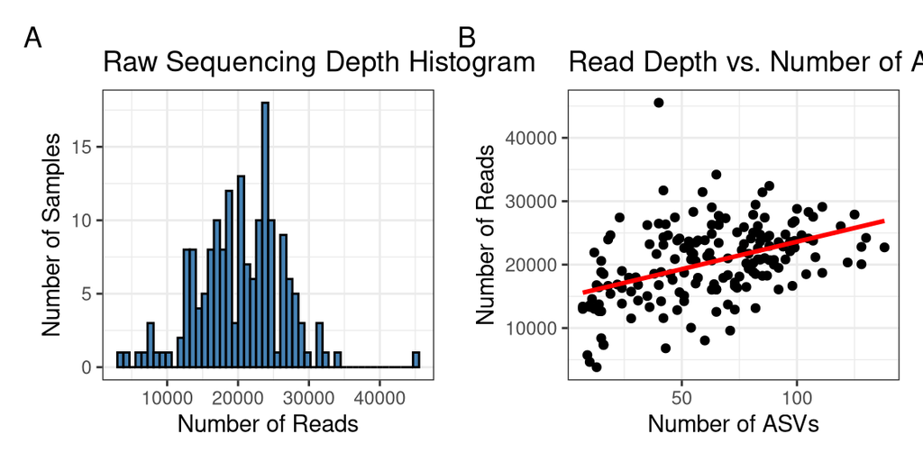

```r
# Plot together
rawSeq_histogram + rawSeq_vs_numASV_plot +
  patchwork::plot_annotation(tag_levels = "A")
```

We chose to normalize sequencing depth using scaling rather than rarefaction.  
Scaling preserves all reads and maintains the original abundance structure of the microbial communities, which is critical for abundance-sensitive analyses like Bray-Curtis and Weighted UniFrac.  
The minimum sequencing depth across samples was 3827 reads, which is sufficient for reliable β-diversity comparisons after scaling.  
Thus, scaling allows us to accurately compare microbial community differences without losing ecological information.

# 3. Scale Read Counts

```r
# Scaling sequencing reads (preserving abundance structure)

# Check the minimum sequencing depth before scaling
min(sample_sums(midpoint_rooted_physeq))
```

```
## [1] 3827
```

```r
# Scale the reads
scaled_physeq <-
  midpoint_rooted_physeq %>%
  scale_reads(round = "matround")

# Quick look at scaled object
scaled_physeq
```

```
## phyloseq-class experiment-level object
## otu_table()   OTU Table:         [ 1160 taxa and 173 samples ]
## sample_data() Sample Data:       [ 173 samples by 52 sample variables ]
## tax_table()   Taxonomy Table:    [ 1160 taxa by 7 taxonomic ranks ]
## phy_tree()    Phylogenetic Tree: [ 1160 tips and 1159 internal nodes ]
```

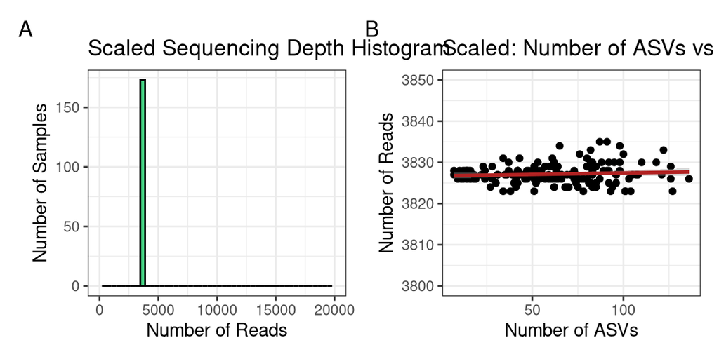

```r
# Confirm sequencing depth after scaling
scaled_TotalSeqs_df <-
  scaled_physeq %>%
  sample_sums() %>%
  data.frame()

# Rename the column
colnames(scaled_TotalSeqs_df)[1] <- "TotalSeqs"

# Add a column: number of ASVs per sample
scaled_TotalSeqsASVs_df <-
  scaled_TotalSeqs_df %>%
  mutate(num_ASVs = colSums(otu_table(scaled_physeq) > 0))

# Plot 1: Histogram of scaled sequencing depth
scaledSeq_histogram <-
  scaled_TotalSeqs_df %>%
  ggplot(aes(x = TotalSeqs)) +
  geom_histogram(bins = 50, fill = "seagreen3", color = "black") +
  labs(title = "Scaled Sequencing Depth Histogram", x = "Number of Reads", y = "Number of Samples") +
  scale_x_continuous(limits = c(0, 20000)) +
  theme_bw()

# Plot 2: Scaled Reads vs Number of ASVs
scaledSeq_vs_numASV_plot <-
  scaled_TotalSeqsASVs_df %>%
  ggplot(aes(x = num_ASVs, y = TotalSeqs)) +
  geom_point() +
  geom_smooth(method = "lm", color = "firebrick") +
  scale_y_continuous(limits = c(3800, 3850)) +
  theme_bw() +
  labs(title = "Scaled: Number of ASVs vs Sequencing Depth", x = "Number of ASVs", y = "Number of Reads")

# Plot together
scaledSeq_histogram + scaledSeq_vs_numASV_plot +
  patchwork::plot_annotation(tag_levels = "A")
```

```r
save(scaled_physeq, file = "data/06_Ordination/scaled_physeq.RData")
```

After scaling the read counts, the total number of sequences across all samples is highly uniform, ranging from 3822 to 3835 reads. During scaling, a small proportion of low-abundance ASVs were removed (1160 taxa retained from 1207 taxa before scaling). The relationship between sequencing depth and ASV richness was further minimized after scaling, indicating that sample diversity is no longer confounded by sequencing effort.

```r
# Fix and Update Sample Metadata in scaled_physeq
# -- Replace sample_data using metadata directly --
source("code/assign_group.R")

# 1. Load metadata
metadata <- read.csv("data/metadata.csv")

# 2. Prepare metadata: add Group
metadata_fixed <-
  metadata %>%
  mutate(Group = sapply(SampleName, assign_group)) %>%
  select(Run, SampleName, Group)  # Only keep needed columns
# 3. Match and arrange metadata to match phyloseq sample order
# (Row names must match the order and names of samples in phyloseq)

# First check sample names
phyloseq_samples <- sample_names(scaled_physeq)

# Filter metadata to only those in phyloseq
metadata_final <-
  metadata_fixed %>%
  filter(Run %in% phyloseq_samples) %>%
  column_to_rownames(var = "Run")  # Run IDs must become rownames

# Check that rows match!
stopifnot(all(rownames(metadata_final) %in% phyloseq_samples))

# 4. Assign metadata into scaled_physeq
sample_data(scaled_physeq) <- sample_data(metadata_final)

# 5. Quick Check
sample_metadata_check <- sample_data(scaled_physeq) %>% data.frame()
head(sample_metadata_check)
```

```
##                SampleName Group
## SRR13060060  A24.2.60_16S  <NA>
## SRR13060061  A24.2.30_16S  <NA>
## SRR13060062 A24.2.180_16S  <NA>
## SRR13060065   A24.2.0_16S  <NA>
## SRR13060066   A24.1.7_16S   RI7
## SRR13060067   A24.1.0_16S   RI0
```

```r
# Check group distribution
sample_metadata_check %>%
  group_by(Group) %>%
  summarise(n_samples = n()) %>%
  arrange(desc(n_samples))
```

```
## # A tibble: 15 × 2
##    Group n_samples
##    <chr>     <int>
##  1 Donor        43
##  2 <NA>         42
##  3 RI7          14
##  4 SI60         12
##  5 RI0          11
##  6 SI7          11
##  7 SI180        10
##  8 SI30         10
##  9 SI0           8
## 10 RI60          4
## 11 RI30          3
## 12 SI90          2
## 13 RI14          1
## 14 RI180         1
## 15 SI4           1
```

# 4. Calculating dissimilarity

```r
# Based on scaled_physeq (already normalized sequencing depth)

# Calculate Sorensen Dissimilarity (presence/absence based)
sorensen_dist <- phyloseq::distance(scaled_physeq, method = "bray", binary = TRUE)

# Quick check
class(sorensen_dist)
```

```
## [1] "dist"
```

```r
str(sorensen_dist)
```

```
##  'dist' num [1:14878] 0.444 0.783 0.662 0.576 0.613 ...
##  - attr(*, "maxdist")= num 1
##  - attr(*, "Size")= int 173
##  - attr(*, "Labels")= chr [1:173] "SRR13060060" "SRR13060061" "SRR13060062" "SRR13060065" ...
##  - attr(*, "Diag")= logi FALSE
##  - attr(*, "Upper")= logi FALSE
##  - attr(*, "method")= chr "binary bray"
##  - attr(*, "call")= language vegdist(x = c(0, 0, 0, 0, 0, 0, 0, 0, 0, 0, 0, 1, 0, 0, 0, 0, 0, 0, 0,  0, 0, 0, 0, 0, 0, 0, 0, 0, 0, 0, 0, 0, 0,| __truncated__ ...
```

```r
# Calculate Bray-Curtis Dissimilarity (abundance-weighted)
bray_dist <- phyloseq::distance(scaled_physeq, method = "bray", binary = FALSE)

# Quick check
class(bray_dist)
```

```
## [1] "dist"
```

```r
str(bray_dist)
```

```
##  'dist' num [1:14878] 0.297 0.651 0.587 0.354 0.655 ...
##  - attr(*, "maxdist")= num 1
##  - attr(*, "Size")= int 173
##  - attr(*, "Labels")= chr [1:173] "SRR13060060" "SRR13060061" "SRR13060062" "SRR13060065" ...
##  - attr(*, "Diag")= logi FALSE
##  - attr(*, "Upper")= logi FALSE
##  - attr(*, "method")= chr "bray"
##  - attr(*, "call")= language vegdist(x = c(0, 0, 0, 0, 0, 0, 0, 0, 0, 0, 0, 1, 0, 0, 0, 0, 0, 0, 0,  0, 0, 0, 0, 0, 0, 0, 0, 0, 0, 0, 0, 0, 0,| __truncated__ ...
```

```r
# Calculate Unweighted UniFrac Dissimilarity (phylogeny + presence/absence)
unweighted_unifrac_dist <- phyloseq::distance(scaled_physeq, method = "unifrac", weighted = FALSE)

# Quick check
class(unweighted_unifrac_dist)
```

```
## [1] "dist"
```

```r
str(unweighted_unifrac_dist)
```

```
##  'dist' num [1:14878] 0.323 0.583 0.499 0.394 0.53 ...
##  - attr(*, "Labels")= chr [1:173] "SRR13060060" "SRR13060061" "SRR13060062" "SRR13060065" ...
##  - attr(*, "Size")= int 173
##  - attr(*, "call")= language as.dist.default(m = UniFracMat)
##  - attr(*, "Diag")= logi FALSE
##  - attr(*, "Upper")= logi FALSE
```

```r
# Calculate Weighted UniFrac Dissimilarity (phylogeny + abundance-weighted)
weighted_unifrac_dist <- phyloseq::distance(scaled_physeq, method = "unifrac", weighted = TRUE)

# Quick check
class(weighted_unifrac_dist)
```

```
## [1] "dist"
```

```r
str(weighted_unifrac_dist)
```

```
##  'dist' num [1:14878] 0.14 0.442 0.343 0.166 0.438 ...
##  - attr(*, "Labels")= chr [1:173] "SRR13060060" "SRR13060061" "SRR13060062" "SRR13060065" ...
##  - attr(*, "Size")= int 173
##  - attr(*, "call")= language as.dist.default(m = UniFracMat)
##  - attr(*, "Diag")= logi FALSE
##  - attr(*, "Upper")= logi FALSE
```

```r
# Save distance matrices for later use
save(sorensen_dist, bray_dist, unweighted_unifrac_dist, weighted_unifrac_dist,
     file = "data/06_Ordination/beta_diversity_distances.RData")
```

For our scientific question - How does RBX2660 treatment alter the gut microbiome structure in patients with recurrent C. difficile infection? - Bray-Curtis and Weighted UniFrac are the most appropriate dissimilarity metrics.

Bray-Curtis is able to capture changes in the relative abundance of microbial taxa, which is critical because successful RBX2660 treatment is expected to not only introduce new taxa but also restore the abundance balance of existing beneficial microbes.

Weighted UniFrac combines abundance and phylogenetic relationships, allowing us to test whether the microbiota of treated patients is more similar to the donor microbiota not only in terms of species abundance, but also in terms of evolutionary lineage structure.

In contrast:

Sorensen and Unweighted UniFrac focus only on presence/absence, ignoring important changes in the dominance or suppression of specific microbiota, and therefore may miss more subtle but biologically meaningful changes after treatment.

Therefore, Bray-Curtis and Weighted UniFrac best capture the microbiome restoration process targeted by RBX2660 therapy.

## Sorensen

```r
# Filter the phyloseq object to key groups only (Donor + RI0/7 + SI0/7)
subset_physeq <- subset_samples(scaled_physeq, Group %in% c("Donor", "RI0", "RI7", "SI0", "SI7"))

subset_physeq <- subset_samples(subset_physeq, !is.na(Group))

# Recalculate Sorensen dissimilarity matrix for subset
sorensen_dist_subset <- phyloseq::distance(subset_physeq, method = "bray", binary = TRUE)

# Then run adonis2 on the filtered subset
sorensen_adonis_terms <- adonis2(
  sorensen_dist_subset ~ Group,
  data = sample_data(subset_physeq) %>% data.frame(),
  permutations = 9999,
  by = "terms"
)
sorensen_adonis_terms
```

```
## Permutation test for adonis under reduced model
## Terms added sequentially (first to last)
## Permutation: free
## Number of permutations: 9999
##
## adonis2(formula = sorensen_dist_subset ~ Group, data = sample_data(subset_physeq) %>% data.frame(), permutations = 9999, by = "terms")
##          Df SumOfSqs      R2      F Pr(>F)
## Group     4   11.643 0.41152 14.335  1e-04 ***
## Residual 82   16.649 0.58848
## Total    86   28.292 1.00000
## ---
## Signif. codes:  0 '***' 0.001 '**' 0.01 '*' 0.05 '.' 0.1 ' ' 1
```

```r
# 2. Model testing by margin (adjusting for other terms)
sorensen_adonis_margin <- adonis2(
  sorensen_dist_subset ~ Group,
  data = sample_data(subset_physeq) %>% data.frame(),
  permutations = 9999,
  by = "margin"
)
sorensen_adonis_margin
```

```
## Permutation test for adonis under reduced model
## Marginal effects of terms
## Permutation: free
## Number of permutations: 9999
##
## adonis2(formula = sorensen_dist_subset ~ Group, data = sample_data(subset_physeq) %>% data.frame(), permutations = 9999, by = "margin")
##          Df SumOfSqs      R2      F Pr(>F)
## Group     4   11.643 0.41152 14.335  1e-04 ***
## Residual 82   16.649 0.58848
## Total    86   28.292 1.00000
## ---
## Signif. codes:  0 '***' 0.001 '**' 0.01 '*' 0.05 '.' 0.1 ' ' 1
```

These results suggest that RBX2660 treatment induces shifts in the **presence or absence** of microbial taxa in the gut microbiome. In other words, not only do abundances change, but new microbial taxa are gained and/or lost during treatment and recovery.

The relatively high R² values indicate that treatment stage (e.g., baseline, post-treatment days) is a major factor structuring gut microbiota composition.

## Bray-Curtis

```r
# PERMANOVA using Bray-Curtis dissimilarity
# Focus on abundance-weighted community differences

# Subset to key groups only
subset_physeq <- subset_samples(scaled_physeq, Group %in% c("Donor", "RI0", "RI7", "SI0", "SI7"))

# Recalculate Bray-Curtis distance on subset
bray_dist_subset <- phyloseq::distance(subset_physeq, method = "bray", binary = FALSE)

# 1. Run adonis2 by terms (sensitive to order)
bray_adonis_terms <- adonis2(
  bray_dist_subset ~ Group,
  data = sample_data(subset_physeq) %>% data.frame(),
  permutations = 9999,
  by = "terms"
)
bray_adonis_terms
```

```
## Permutation test for adonis under reduced model
## Terms added sequentially (first to last)
## Permutation: free
## Number of permutations: 9999
##
## adonis2(formula = bray_dist_subset ~ Group, data = sample_data(subset_physeq) %>% data.frame(), permutations = 9999, by = "terms")
##          Df SumOfSqs      R2      F Pr(>F)
## Group     4   10.786 0.34402 10.751  1e-04 ***
## Residual 82   20.568 0.65598
## Total    86   31.354 1.00000
## ---
## Signif. codes:  0 '***' 0.001 '**' 0.01 '*' 0.05 '.' 0.1 ' ' 1
```

```r
# 2. Run adonis2 by margin (adjusted p-values)
bray_adonis_margin <- adonis2(
  bray_dist_subset ~ Group,
  data = sample_data(subset_physeq) %>% data.frame(),
  permutations = 9999,
  by = "margin"
)
bray_adonis_margin
```

```
## Permutation test for adonis under reduced model
## Marginal effects of terms
## Permutation: free
## Number of permutations: 9999
##
## adonis2(formula = bray_dist_subset ~ Group, data = sample_data(subset_physeq) %>% data.frame(), permutations = 9999, by = "margin")
##          Df SumOfSqs      R2      F Pr(>F)
## Group     4   10.786 0.34402 10.751  1e-04 ***
## Residual 82   20.568 0.65598
## Total    86   31.354 1.00000
## ---
## Signif. codes:  0 '***' 0.001 '**' 0.01 '*' 0.05 '.' 0.1 ' ' 1
```

Compared to the Sorensen analysis (which focuses on presence/absence), Bray-Curtis captures shifts in the **relative abundances** of taxa between groups.

The result indicates that not only were new taxa gained or lost after RBX2660 treatment, but also the relative abundances of existing microbial populations changed substantially.

The relatively high R² and strong F-statistic support the conclusion that RBX2660 therapy drives major reorganization of gut microbiota structure at the level of both presence/absence and abundance.

Thus, these results provide compelling evidence that RBX2660 significantly reshapes the gut microbiome composition in patients with recurrent C. difficile infection.

## Sorensen

```r
# Subset phyloseq object ---
subset_physeq <- subset_samples(scaled_physeq, Group %in% c("Donor", "RI0", "RI7", "SI0", "SI7"))

# Calculate Sorensen distance matrix ---
sorensen_dist_subset <- phyloseq::distance(subset_physeq, method = "bray", binary = TRUE)

# Extract metadata for subset ---
metadata_subset <- sample_data(subset_physeq) %>% data.frame()

# Betadisper analysis ---

# Test by Group
dispr_sorensen_group <- betadisper(sorensen_dist_subset, metadata_subset$Group)

# permutest significance testing
permutest(dispr_sorensen_group, permutations = 9999)
```

```
##
## Permutation test for homogeneity of multivariate dispersions
## Permutation: free
## Number of permutations: 9999
##
## Response: Distances
##           Df  Sum Sq  Mean Sq      F N.Perm Pr(>F)
## Groups     4 0.71385 0.178462 31.998   9999  1e-04 ***
## Residuals 82 0.45734 0.005577
## ---
## Signif. codes:  0 '***' 0.001 '**' 0.01 '*' 0.05 '.' 0.1 ' ' 1
```

```r
# summary
summary(dispr_sorensen_group)
```

```
##                 Length Class  Mode
## eig               86   -none- numeric
## vectors         7482   -none- numeric
## distances         87   -none- numeric
## group             87   factor numeric
## centroids        430   -none- numeric
## group.distances    5   -none- numeric
## call               3   -none- call
```

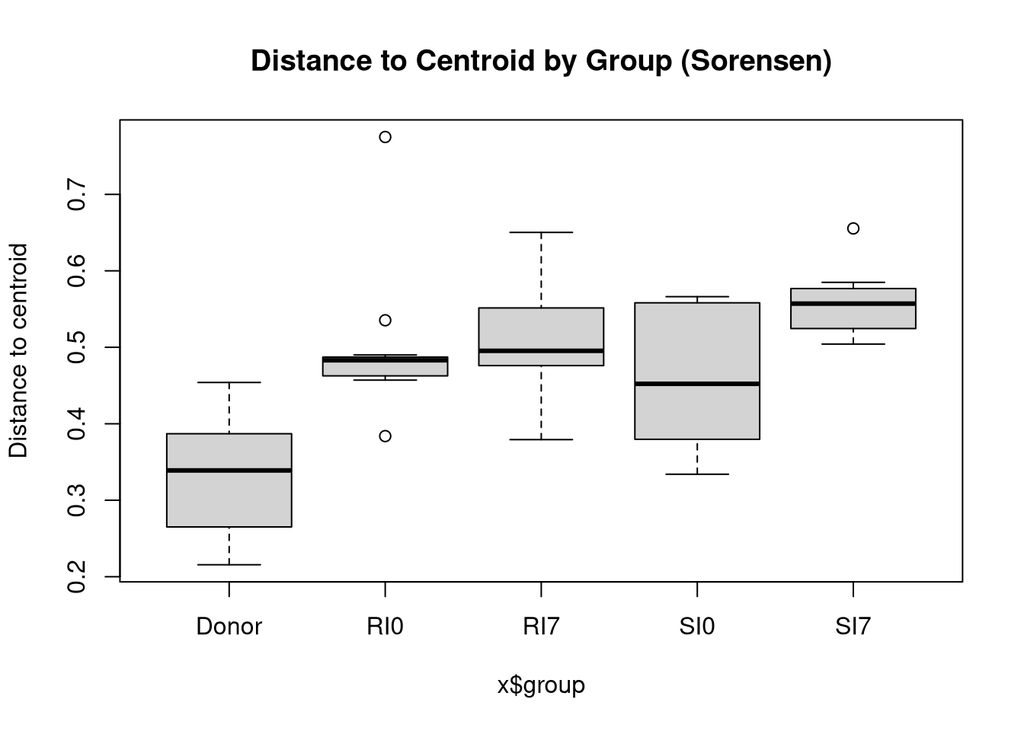

```r
# Visualize
library(ggplot2)
boxplot(dispr_sorensen_group, main = "Distance to Centroid by Group (Sorensen)")
```

## Bray-Curtis

```r
# Subset phyloseq object ---
subset_physeq <- subset_samples(scaled_physeq, Group %in% c("Donor", "RI0", "RI7", "SI0", "SI7"))

# Calculate Bray-Curtis distance matrix ---
bray_dist_subset <- phyloseq::distance(subset_physeq, method = "bray", binary = FALSE)

# Extract metadata for subset ---
metadata_subset <- sample_data(subset_physeq) %>% data.frame()

# Betadisper analysis ---

# Test by Group
dispr_bray_group <- betadisper(bray_dist_subset, metadata_subset$Group)

# permutest significance testing
permutest(dispr_bray_group, permutations = 9999)
```

```
##
## Permutation test for homogeneity of multivariate dispersions
## Permutation: free
## Number of permutations: 9999
##
## Response: Distances
##           Df  Sum Sq  Mean Sq      F N.Perm Pr(>F)
## Groups     4 1.23728 0.309320 54.679   9999  1e-04 ***
## Residuals 82 0.46388 0.005657
## ---
## Signif. codes:  0 '***' 0.001 '**' 0.01 '*' 0.05 '.' 0.1 ' ' 1
```

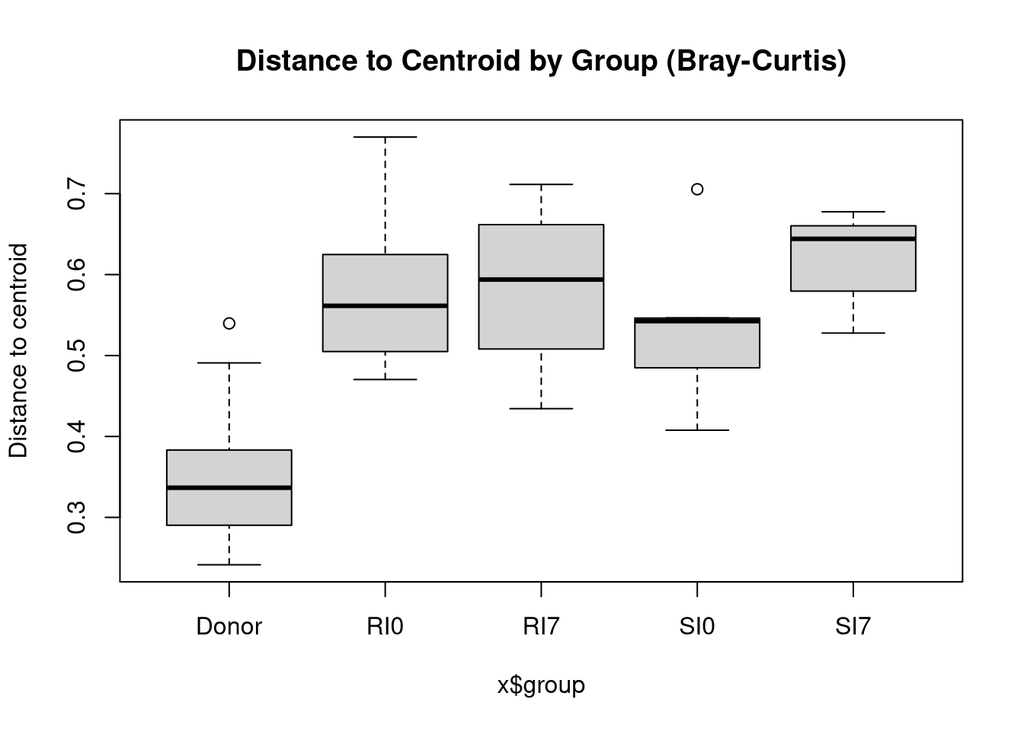

```r
# Visualization
boxplot(dispr_bray_group, main = "Distance to Centroid by Group (Bray-Curtis)")
```

We tested the homogeneity of group dispersions using the betadisper() and permutest() functions for both Sorensen and Bray-Curtis distances.

- For Sorensen dissimilarity (presence/absence), the dispersion test was significant (p < 0.0001), indicating that the variability of microbial communities within groups differs significantly.
- For Bray-Curtis dissimilarity (abundance-weighted), the dispersion test was also significant (p < 0.0001), suggesting heterogeneity of variance across groups.

These results mean that there are real differences in how variable the microbiota are within different groups (e.g., Donor, RI0, RI7, SI0, SI7).  
Thus, some of the differences detected by PERMANOVA could partly arise from differences in within-group variability rather than only differences in group centroids.

Given that both PERMANOVA and Betadisper tests were significant, we must interpret the observed shifts in microbiota composition after RBX2660 treatment with caution.

- The PERMANOVA tests confirmed significant differences in microbiota structure between donor and patient groups (p < 0.0001 for both Sorensen and Bray-Curtis distances).
- However, the significant betadisper results indicate that these differences could be influenced both by shifts in community centroids (true compositional differences) and by changes in within-group dispersion (community variability).

Biological interpretation: RBX2660 treatment likely drives genuine changes in gut microbial composition, moving patient communities closer to donor profiles.  
However, the treatment may also cause changes in the consistency of microbial communities within patient groups — potentially reflecting biological heterogeneity in patient responses to therapy.

To strengthen these conclusions, we will visualize ordination plots (PCoA and NMDS) to check if group centroids are truly separated.

# 6a. PCoA: Principal Coordinates Analysis

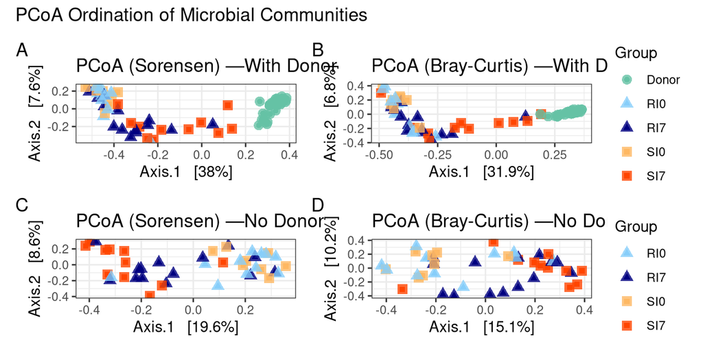

```r
# Subset data (With Donor and Without Donor) ---
subset_physeq_with_donor <- subset_samples(scaled_physeq, Group %in% c("Donor", "RI0", "RI7", "SI0", "SI7"))
subset_physeq_nodonor <- subset_samples(scaled_physeq, Group %in% c("RI0", "RI7", "SI0", "SI7"))

# Ordinate PCoA ---
subset_soren_pcoa_with_donor <- ordinate(subset_physeq_with_donor, method = "PCoA", distance = "bray", binary = TRUE)
subset_bray_pcoa_with_donor  <- ordinate(subset_physeq_with_donor, method = "PCoA", distance = "bray", binary = FALSE)

subset_soren_pcoa_nodonor <- ordinate(subset_physeq_nodonor, method = "PCoA", distance = "bray", binary = TRUE)
subset_bray_pcoa_nodonor  <- ordinate(subset_physeq_nodonor, method = "PCoA", distance = "bray", binary = FALSE)

# Define colors and shapes ---
group_colors_with_donor <- c("Donor"="#66C2A5", "RI0"="#87CEFA", "RI7"="#000080", "SI0"="#FDB863", "SI7"="#FF4500")
group_shapes_with_donor <- c("Donor"=16, "RI0"=17, "RI7"=17, "SI0"=15, "SI7"=15)

group_colors_nodonor <- c("RI0"="#87CEFA", "RI7"="#000080", "SI0"="#FDB863", "SI7"="#FF4500")
group_shapes_nodonor <- c("RI0"=17, "RI7"=17, "SI0"=15, "SI7"=15)

# PCoA Plots WITH Donor ---
sorensen_pcoa_plot_with_donor <- plot_ordination(
  subset_physeq_with_donor, subset_soren_pcoa_with_donor, color = "Group", shape = "Group"
) +
  geom_point(size=3, alpha=0.8) +
  scale_color_manual(values = group_colors_with_donor) +
  scale_shape_manual(values = group_shapes_with_donor) +
  labs(title = "PCoA (Sorensen) —With Donor") +
  theme_bw()

bray_pcoa_plot_with_donor <- plot_ordination(
  subset_physeq_with_donor, subset_bray_pcoa_with_donor, color = "Group", shape = "Group"
) +
  geom_point(size=3, alpha=0.8) +
  scale_color_manual(values = group_colors_with_donor) +
  scale_shape_manual(values = group_shapes_with_donor) +
  labs(title = "PCoA (Bray-Curtis) —With Donor") +
  theme_bw()

# PCoA Plots WITHOUT Donor ---
sorensen_pcoa_plot_nodonor <- plot_ordination(
  subset_physeq_nodonor, subset_soren_pcoa_nodonor, color = "Group", shape = "Group"
) +
  geom_point(size=3, alpha=0.8) +
  scale_color_manual(values = group_colors_nodonor) +
  scale_shape_manual(values = group_shapes_nodonor) +
  labs(title = "PCoA (Sorensen) —No Donor") +
  theme_bw()

bray_pcoa_plot_nodonor <- plot_ordination(
  subset_physeq_nodonor, subset_bray_pcoa_nodonor, color = "Group", shape = "Group"
) +
  geom_point(size=3, alpha=0.8) +
  scale_color_manual(values = group_colors_nodonor) +
  scale_shape_manual(values = group_shapes_nodonor) +
  labs(title = "PCoA (Bray-Curtis) —No Donor") +
  theme_bw()

library(patchwork)

# Combine 4 PCoA plots: Sorensen & Bray, With Donor & No Donor
(sorensen_pcoa_plot_with_donor + bray_pcoa_plot_with_donor) /
(sorensen_pcoa_plot_nodonor + bray_pcoa_plot_nodonor) +
  patchwork::plot_layout(guides = "collect") +
  patchwork::plot_annotation(tag_levels = "A", title = "PCoA Ordination of Microbial Communities")
```

Based on the first PCoA plot (including Donor group) In the PCoA plots including Donor samples (Sorensen and Bray-Curtis metrics), a clear and biologically meaningful pattern emerges:

RI0 and SI0 samples (pre-treatment) are clustered far away from Donor samples, indicating that patients with recurrent C. difficile infection harbor gut microbiota highly distinct from healthy donors.

RI7 and SI7 samples (post-treatment) shift closer toward the Donor cluster along the first principal coordinate (Axis 1), suggesting that RBX2660 treatment successfully shifted the gut microbiome composition toward a donor-like, healthy community structure.

This directional shift is consistent across both presence/absence (Sorensen) and abundance-weighted (Bray-Curtis) metrics.

Based on the second PCoA plot (after removing Donor group) After removing Donor samples and re-plotting the PCoA:

The patient groups (RI0, RI7, SI0, SI7) are more evenly distributed across the ordination space.

RI0 vs RI7 and SI0 vs SI7 still exhibit some separation, particularly along Axis 1, but the patterns are less stark compared to when Donor samples were present.

The removal of the dominant Donor cluster allows for finer-grained exploration of patient-to-patient variability, but also highlights heterogeneity in patient responses to RBX2660 treatment, especially within the RI group.

## 6b. NMDS: Non-Metric Multidimensional Scaling

```r
# Subset data (With Donor and Without Donor) ---
subset_physeq_with_donor <- subset_samples(scaled_physeq, Group %in% c("Donor", "RI0", "RI7", "SI0", "SI7"))
subset_physeq_nodonor <- subset_samples(scaled_physeq, Group %in% c("RI0", "RI7", "SI0", "SI7"))

# Ordinate NMDS ---
subset_soren_nmds_with_donor <- ordinate(subset_physeq_with_donor, method = "NMDS", distance = "bray", binary = TRUE)
```

```
## Square root transformation
## Wisconsin double standardization
## *** Best solution was not repeated -- monoMDS stopping criteria:
##      1: no. of iterations >= maxit
##     17: stress ratio > sratmax
##      2: scale factor of the gradient < sfgrmin
```

```r
subset_bray_nmds_with_donor  <- ordinate(subset_physeq_with_donor, method = "NMDS", distance = "bray", binary = FALSE)
```

```
## Square root transformation
## Wisconsin double standardization
## *** Best solution was not repeated -- monoMDS stopping criteria:
##     19: stress ratio > sratmax
##      1: scale factor of the gradient < sfgrmin
```

```r
subset_soren_nmds_nodonor <- ordinate(subset_physeq_nodonor, method = "NMDS", distance = "bray", binary = TRUE)
```

```
## Square root transformation
## Wisconsin double standardization
## *** Best solution was not repeated -- monoMDS stopping criteria:
##     20: stress ratio > sratmax
```

```r
subset_bray_nmds_nodonor  <- ordinate(subset_physeq_nodonor, method = "NMDS", distance = "bray", binary = FALSE)
```

```
## Square root transformation
## Wisconsin double standardization
## *** Best solution was not repeated -- monoMDS stopping criteria:
##     20: stress ratio > sratmax
```

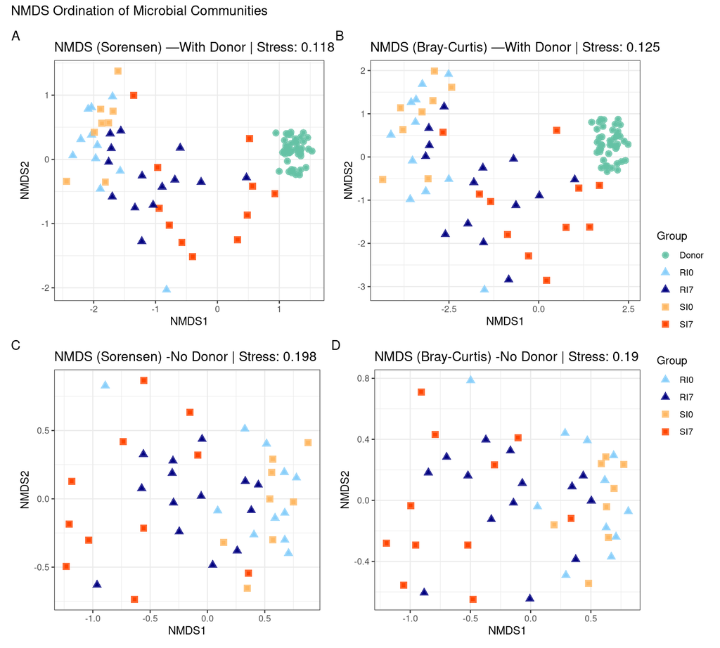

```r
# Define colors and shapes ---
group_colors_with_donor <- c("Donor"="#66C2A5", "RI0"="#87CEFA", "RI7"="#000080", "SI0"="#FDB863", "SI7"="#FF4500")
group_shapes_with_donor <- c("Donor"=16, "RI0"=17, "RI7"=17, "SI0"=15, "SI7"=15)

group_colors_nodonor <- c("RI0"="#87CEFA", "RI7"="#000080", "SI0"="#FDB863", "SI7"="#FF4500")
group_shapes_nodonor <- c("RI0"=17, "RI7"=17, "SI0"=15, "SI7"=15)

# NMDS Plots WITH Donor ---
sorensen_nmds_plot_with_donor <- plot_ordination(
  subset_physeq_with_donor, subset_soren_nmds_with_donor, color = "Group", shape = "Group"
) +
  geom_point(size=3, alpha=0.8) +
  scale_color_manual(values = group_colors_with_donor) +
  scale_shape_manual(values = group_shapes_with_donor) +
  labs(title = paste0("NMDS (Sorensen) —With Donor | Stress: ", round(subset_soren_nmds_with_donor$stress, 3))) +
  theme_bw()

bray_nmds_plot_with_donor <- plot_ordination(
  subset_physeq_with_donor, subset_bray_nmds_with_donor, color = "Group", shape = "Group"
) +
  geom_point(size=3, alpha=0.8) +
  scale_color_manual(values = group_colors_with_donor) +
  scale_shape_manual(values = group_shapes_with_donor) +
  labs(title = paste0("NMDS (Bray-Curtis) —With Donor | Stress: ", round(subset_bray_nmds_with_donor$stress, 3))) +
  theme_bw()

# NMDS Plots WITHOUT Donor ---
sorensen_nmds_plot_nodonor <- plot_ordination(
  subset_physeq_nodonor, subset_soren_nmds_nodonor, color = "Group", shape = "Group"
) +
  geom_point(size=3, alpha=0.8) +
  scale_color_manual(values = group_colors_nodonor) +
  scale_shape_manual(values = group_shapes_nodonor) +
  labs(title = paste0("NMDS (Sorensen) -No Donor | Stress: ", round(subset_soren_nmds_nodonor$stress, 3))) +
  theme_bw()

bray_nmds_plot_nodonor <- plot_ordination(
  subset_physeq_nodonor, subset_bray_nmds_nodonor, color = "Group", shape = "Group"
) +
  geom_point(size=3, alpha=0.8) +
  scale_color_manual(values = group_colors_nodonor) +
  scale_shape_manual(values = group_shapes_nodonor) +
  labs(title = paste0("NMDS (Bray-Curtis) -No Donor | Stress: ", round(subset_bray_nmds_nodonor$stress, 3))) +
  theme_bw()

# Combine 4 NMDS plots: Sorensen & Bray, With Donor & No Donor
library(patchwork)

(sorensen_nmds_plot_with_donor + bray_nmds_plot_with_donor) /
(sorensen_nmds_plot_nodonor + bray_nmds_plot_nodonor) +
  patchwork::plot_layout(guides = "collect") +
  patchwork::plot_annotation(tag_levels = "A", title = "NMDS Ordination of Microbial Communities")
```

Using NMDS ordination, we explored patterns in beta diversity among key groups (Donor, RI0, RI7, SI0, SI7).

In the first NMDS plot (with Donor samples included):

Donor samples clustered very tightly, indicating low within-group variability among healthy donors.

Patients at baseline (RI0 and SI0) were clearly separated from the Donor cluster, reflecting microbiome disruption before treatment.

Stress values (0.118 for Sorensen and 0.125 for Bray-Curtis) were low, supporting reliable interpretation.

In the second NMDS plot (Donor samples excluded):

The overall trend remained: SI7 samples separated from SI0, moving toward a healthier community structure.

RI7 samples displayed greater overlap with RI0 samples and greater spread, highlighting higher variability and incomplete recovery among patients who later experienced recurrence.

Stress values (~0.198) were higher but still acceptable for ecological interpretation, with caution.

## All ordinations together!

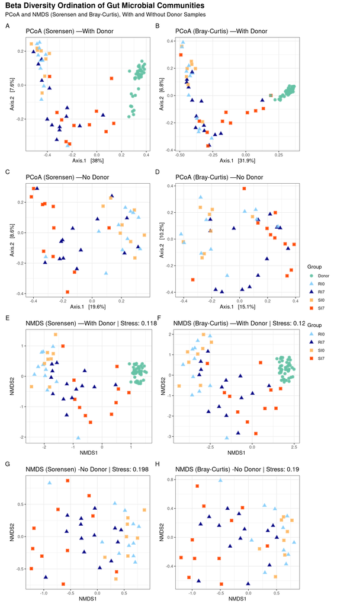

```r
(
  (sorensen_pcoa_plot_with_donor + bray_pcoa_plot_with_donor) /
  (sorensen_pcoa_plot_nodonor + bray_pcoa_plot_nodonor) /
  (sorensen_nmds_plot_with_donor + bray_nmds_plot_with_donor) /
  (sorensen_nmds_plot_nodonor + bray_nmds_plot_nodonor)
) +
  patchwork::plot_layout(guides = "collect") +
  patchwork::plot_annotation(
    title = "Beta Diversity Ordination of Gut Microbial Communities",
    subtitle = "PCoA and NMDS (Sorensen and Bray-Curtis), With and Without Donor Samples",
    tag_levels = "A",
    theme = theme(plot.title = element_text(size=16, face="bold"),
                  plot.subtitle = element_text(size=12))
  )
```

Overall comparison:

PCoA plots show a very clear directional shift along Axis 1.

When Donor samples are included, pre-treatment samples (RI0, SI0) are clearly separated from Donor, and post-treatment samples (RI7, SI7) shift closer toward the Donor cluster.

After removing Donor samples, the separation between SI0 and SI7 remains somewhat clear, while RI0 and RI7 are more intermixed.

NMDS plots also reveal the same biological trend, but:

NMDS spreads the samples out differently.

The structure is slightly less “compressed” than PCoA (especially along NMDS1 axis).

Which visualization works best?

PCoA works better for this dataset.

Reason:

The first principal coordinate (Axis 1) explains a large proportion of the variance (~30%), making the horizontal shift toward the Donor cluster visually very striking.

PCoA cleanly separates pre- and post-treatment samples when Donor is included.

NMDS, while still valid, introduces more distortion due to its rank-based, non-metric nature, and the slightly higher stress (~0.195) suggests a bit more caution.

Conclusion:

PCoA is the preferred ordination method here because it provides clearer, more interpretable clustering and separation between groups.

NMDS supports and validates the findings but is slightly noisier.

Using both approaches together strengthens the robustness of the conclusions.

# Final info for Reproducibility

## Check Render Time

```r
# Take the time now that we are at the end of the script
end_time <- Sys.time()
end_time
```

```
## [1] "2025-04-29 12:39:55 EDT"
```

```r
# Echo the elapsed time
elapsed_time <- round((end_time - start_time), 3)
elapsed_time
```

```
## Time difference of 29.301 secs
```